# Credit Card Segmentation

Shraddha

10/05/2020

Credit card segmentation

```r
data<-read.csv("C:/Users/Shraddha/Desktop/Revmax_data.csv")
```

Firstly, we will check for the dimensions and missing values in the dataset.

```r
dim(data)
```

```
## [1] 8950   18
```

```r
sum(is.na(data))
```

```
## [1] 314
```

```r
colSums(is.na(data))
```

```
##                          CUST_ID                          BALANCE
##                                0                                0
##                BALANCE_FREQUENCY                        PURCHASES
##                                0                                0
##                 ONEOFF_PURCHASES           INSTALLMENTS_PURCHASES
##                                0                                0
##                     CASH_ADVANCE              PURCHASES_FREQUENCY
##                                0                                0
##       ONEOFF_PURCHASES_FREQUENCY PURCHASES_INSTALLMENTS_FREQUENCY
##                                0                                0
##           CASH_ADVANCE_FREQUENCY                 CASH_ADVANCE_TRX
##                                0                                0
##                    PURCHASES_TRX                     CREDIT_LIMIT
##                                0                                1
##                         PAYMENTS                 MINIMUM_PAYMENTS
##                                0                              313
##                 PRC_FULL_PAYMENT                           TENURE
##                                0                                0
```

```r
clean_data<-na.omit(data)
sum(is.na(clean_data))
```

```
## [1] 0
```

Now, we will find out if there are any categorical variables that may need transforming. We can see from the result that all features are numeric except for “CUST ID”. Since it is a unique variable and we can’t get further information from it.

```r
str(clean_data)
```

```
## 'data.frame':    8636 obs. of  18 variables:
##  $ CUST_ID                         : Factor w/ 8950 levels "C10001","C10002",..: 1 2 3 5 6 7 8 9 10 11 ...
##  $ BALANCE                         : num  40.9 3202.5 2495.1 817.7 1809.8 ...
##  $ BALANCE_FREQUENCY               : num  0.818 0.909 1 1 1 ...
##  $ PURCHASES                       : num  95.4 0 773.2 16 1333.3 ...
##  $ ONEOFF_PURCHASES                : num  0 0 773 16 0 ...
##  $ INSTALLMENTS_PURCHASES          : num  95.4 0 0 0 1333.3 ...
##  $ CASH_ADVANCE                    : num  0 6443 0 0 0 ...
##  $ PURCHASES_FREQUENCY             : num  0.1667 0 1 0.0833 0.6667 ...
##  $ ONEOFF_PURCHASES_FREQUENCY      : num  0 0 1 0.0833 0 ...
##  $ PURCHASES_INSTALLMENTS_FREQUENCY: num  0.0833 0 0 0 0.5833 ...
##  $ CASH_ADVANCE_FREQUENCY          : num  0 0.25 0 0 0 0 0 0 0 0 ...
##  $ CASH_ADVANCE_TRX                : int  0 4 0 0 0 0 0 0 0 0 ...
##  $ PURCHASES_TRX                   : int  2 0 12 1 8 64 12 5 3 12 ...
##  $ CREDIT_LIMIT                    : num  1000 7000 7500 1200 1800 13500 2300 7000 11000 1200 ...
##  $ PAYMENTS                        : num  202 4103 622 678 1400 ...
##  $ MINIMUM_PAYMENTS                : num  140 1072 627 245 2407 ...
##  $ PRC_FULL_PAYMENT                : num  0 0.222 0 0 0 ...
##  $ TENURE                          : int  12 12 12 12 12 12 12 12 12 12 ...
##  - attr(*, "na.action")= 'omit' Named int  4 46 48 55 56 57 64 94 95 98 ...
##   ..- attr(*, "names")= chr  "4" "46" "48" "55" ...
```

```r
clean_data<-clean_data[-1]
```

```r
head(clean_data)
```

```
##      BALANCE BALANCE_FREQUENCY PURCHASES ONEOFF_PURCHASES
## 1   40.90075          0.818182     95.40             0.00
## 2 3202.46742          0.909091      0.00             0.00
## 3 2495.14886          1.000000    773.17           773.17
## 5  817.71434          1.000000     16.00            16.00
## 6 1809.82875          1.000000   1333.28             0.00
## 7  627.26081          1.000000   7091.01          6402.63
##   INSTALLMENTS_PURCHASES CASH_ADVANCE PURCHASES_FREQUENCY
## 1                  95.40        0.000            0.166667
## 2                   0.00     6442.945            0.000000
## 3                   0.00        0.000            1.000000
## 5                   0.00        0.000            0.083333
## 6                1333.28        0.000            0.666667
## 7                 688.38        0.000            1.000000
##   ONEOFF_PURCHASES_FREQUENCY PURCHASES_INSTALLMENTS_FREQUENCY
```

[output cut: 20 more lines]

```r
View(clean_data)
dim(clean_data)
```

```
## [1] 8636   17
```

**Advanced data preparation**  
Key Performance Indicators(KPI’s) are set of measures that shows performance of overall buisness.

1. Monthly average purchase and cash advance amount

Monthly average purchase

```r
clean_data$MONTHLY_AVG_PURCHASE<-clean_data$PURCHASES/clean_data$TENURE
```

monthly cash advanced amount

```r
clean_data$MONTHLY_ADV_AMOUNT<-clean_data$CASH_ADVANCE/clean_data$TENURE
```

2. Purchases by type (one-off, installments)

We found out that there are 4 types of purchase behaviour in the data set. So we need to derive a categorical variable based on their behaviour.  
1) No purchase use  
2) Installment purchases  
3) One-off purchases  
4) Both (one-off and installment) purchase use

```r
length(clean_data$ONEOFF_PURCHASES[clean_data$ONEOFF_PURCHASES==0])
```

```
## [1] 4113
```

```r
length(clean_data$INSTALLMENTS_PURCHASES[clean_data$INSTALLMENTS_PURCHASES==0])
```

```
## [1] 3747
```

```r
table(clean_data$ONEOFF_PURCHASES==0 & clean_data$INSTALLMENTS_PURCHASES==0)
```

```
##
## FALSE  TRUE
##  6671  1965
```

```r
table(clean_data$ONEOFF_PURCHASES>0 & clean_data$INSTALLMENTS_PURCHASES>0)
```

```
##
## FALSE  TRUE
##  5895  2741
```

```r
table(clean_data$ONEOFF_PURCHASES>0 & clean_data$INSTALLMENTS_PURCHASES==0)
```

```
##
## FALSE  TRUE
##  6854  1782
```

```r
table(clean_data$ONEOFF_PURCHASES>0 & clean_data$INSTALLMENTS_PURCHASES>0)
```

```
##
## FALSE  TRUE
##  5895  2741
```

3. Average amount per purchase and cash advance transaction.  
   Those are already given in the data set.

```r
head(PURCHASES_TRX)
```

[output not shown]

```r
head(CASH_ADVANCE_TRX)
```

[output not shown]

4. Limit usage (balance to clean_data limit ratio)  
   (LOWER VALUE=GOOD data SCORE)The calculation is your data card balances divided by the total clean_data card limits. A debt ratio below 30% is considered “good” by FICO and will help improve one’s data score

```r
clean_data$Limit_usage<-clean_data$BALANCE/clean_data$CREDIT_LIMIT
clean_data_limit_ratio<-clean_data$Limit_usage*100
table(clean_data_limit_ratio<30)
```

```
##
## FALSE  TRUE
##  4443  4193
```

5. Payments to minimum payments ratio etc.

```r
clean_data$minpay_ratio<-clean_data$PAYMENTS/clean_data$MINIMUM_PAYMENTS
head(clean_data$minpay_ratio)
```

```
## [1]  1.4465084  3.8262415  0.9916815  2.7710745  0.5816014 32.0818198
```

**Outliers**

Using IQR method to remove outliers

```r
summary(clean_data)
```

```
##     BALANCE        BALANCE_FREQUENCY   PURCHASES        ONEOFF_PURCHASES
##  Min.   :    0.0   Min.   :0.0000    Min.   :    0.00   Min.   :    0.00
##  1st Qu.:  148.1   1st Qu.:0.9091    1st Qu.:   43.37   1st Qu.:    0.00
##  Median :  916.9   Median :1.0000    Median :  375.40   Median :   44.99
##  Mean   : 1601.2   Mean   :0.8950    Mean   : 1025.43   Mean   :  604.90
##  3rd Qu.: 2105.2   3rd Qu.:1.0000    3rd Qu.: 1145.98   3rd Qu.:  599.10
##  Max.   :19043.1   Max.   :1.0000    Max.   :49039.57   Max.   :40761.25
##  INSTALLMENTS_PURCHASES  CASH_ADVANCE     PURCHASES_FREQUENCY
##  Min.   :    0.00       Min.   :    0.0   Min.   :0.00000
##  1st Qu.:    0.00       1st Qu.:    0.0   1st Qu.:0.08333
##  Median :   94.78       Median :    0.0   Median :0.50000
##  Mean   :  420.84       Mean   :  994.2   Mean   :0.49600
##  3rd Qu.:  484.15       3rd Qu.: 1132.4   3rd Qu.:0.91667
##  Max.   :22500.00       Max.   :47137.2   Max.   :1.00000
##  ONEOFF_PURCHASES_FREQUENCY PURCHASES_INSTALLMENTS_FREQUENCY
##  Min.   :0.00000            Min.   :0.0000
##  1st Qu.:0.00000            1st Qu.:0.0000
##  Median :0.08333            Median :0.1667
##  Mean   :0.20591            Mean   :0.3688
##  3rd Qu.:0.33333            3rd Qu.:0.7500
##  Max.   :1.00000            Max.   :1.0000
##  CASH_ADVANCE_FREQUENCY CASH_ADVANCE_TRX  PURCHASES_TRX     CREDIT_LIMIT
##  Min.   :0.0000         Min.   :  0.000   Min.   :  0.00   Min.   :   50
##  1st Qu.:0.0000         1st Qu.:  0.000   1st Qu.:  1.00   1st Qu.: 1600
##  Median :0.0000         Median :  0.000   Median :  7.00   Median : 3000
##  Mean   :0.1376         Mean   :  3.314   Mean   : 15.03   Mean   : 4522
##  3rd Qu.:0.2500         3rd Qu.:  4.000   3rd Qu.: 18.00   3rd Qu.: 6500
##  Max.   :1.5000         Max.   :123.000   Max.   :358.00   Max.   :30000
##     PAYMENTS        MINIMUM_PAYMENTS   PRC_FULL_PAYMENT     TENURE
##  Min.   :    0.05   Min.   :    0.02   Min.   :0.0000   Min.   : 6.00
##  1st Qu.:  418.56   1st Qu.:  169.16   1st Qu.:0.0000   1st Qu.:12.00
##  Median :  896.68   Median :  312.45   Median :0.0000   Median :12.00
##  Mean   : 1784.48   Mean   :  864.30   Mean   :0.1593   Mean   :11.53
##  3rd Qu.: 1951.14   3rd Qu.:  825.50   3rd Qu.:0.1667   3rd Qu.:12.00
##  Max.   :50721.48   Max.   :76406.21   Max.   :1.0000   Max.   :12.00
##  MONTHLY_AVG_PURCHASE MONTHLY_ADV_AMOUNT  Limit_usage        minpay_ratio
##  Min.   :   0.00      Min.   :   0.00    Min.   : 0.00000   Min.   :   0.001
##  1st Qu.:   3.75      1st Qu.:   0.00    1st Qu.: 0.04741   1st Qu.:   0.958
##  Median :  33.21      Median :   0.00    Median : 0.31826   Median :   2.171
##  Mean   :  88.02      Mean   :  90.25    Mean   : 0.39772   Mean   :   9.351
##  3rd Qu.:  99.88      3rd Qu.: 101.02    3rd Qu.: 0.72575   3rd Qu.:   6.262
##  Max.   :4086.63      Max.   :3928.10    Max.   :15.90995   Max.   :6840.529
```

```r
remove_outliers<- function(a) {
    sdv <- sd(a)
    q1<-quantile(a,0.25)
    q3<-quantile(a,0.75)
    H<-1.5*IQR(a)
    min <- min(a)
    max <- max(a)
    UB <- q3+H
    LB <-q1-H
    outlier_flag<- max>UB | min<LB
    return(c(outlier_flag=outlier_flag,min = min,q1=q1,q3=q3,max=max, UB=UB, LB=LB ))
}

Outliers<-t(data.frame(apply(clean_data,2,remove_outliers)))
round(Outliers,3)
```

```
##                                  outlier_flag.75%    min   q1.25%   q3.75%
## BALANCE                                         1  0.000  148.095 2105.196
## BALANCE_FREQUENCY                               1  0.000    0.909    1.000
## PURCHASES                                       1  0.000   43.368 1145.980
## ONEOFF_PURCHASES                                1  0.000    0.000  599.100
## INSTALLMENTS_PURCHASES                          1  0.000    0.000  484.148
## CASH_ADVANCE                                    1  0.000    0.000 1132.385
## PURCHASES_FREQUENCY                             0  0.000    0.083    0.917
## ONEOFF_PURCHASES_FREQUENCY                      1  0.000    0.000    0.333
## PURCHASES_INSTALLMENTS_FREQUENCY                0  0.000    0.000    0.750
## CASH_ADVANCE_FREQUENCY                          1  0.000    0.000    0.250
## CASH_ADVANCE_TRX                                1  0.000    0.000    4.000
## PURCHASES_TRX                                   1  0.000    1.000   18.000
## CREDIT_LIMIT                                    1 50.000 1600.000 6500.000
## PAYMENTS                                        1  0.050  418.559 1951.142
## MINIMUM_PAYMENTS                                1  0.019  169.164  825.496
## PRC_FULL_PAYMENT                                1  0.000    0.000    0.167
## TENURE                                          1  6.000   12.000   12.000
## MONTHLY_AVG_PURCHASE                            1  0.000    3.750   99.876
## MONTHLY_ADV_AMOUNT                              1  0.000    0.000  101.016
## Limit_usage                                     1  0.000    0.047    0.726
## minpay_ratio                                    1  0.001    0.958    6.262
##                                        max    UB.75%    LB.25%
## BALANCE                          19043.139  5040.847 -2787.556
## BALANCE_FREQUENCY                    1.000     1.136     0.773
## PURCHASES                        49039.570  2799.899 -1610.551
## ONEOFF_PURCHASES                 40761.250  1497.750  -898.650
## INSTALLMENTS_PURCHASES           22500.000  1210.369  -726.221
## CASH_ADVANCE                     47137.212  2830.964 -1698.578
## PURCHASES_FREQUENCY                  1.000     2.167    -1.167
## ONEOFF_PURCHASES_FREQUENCY           1.000     0.833    -0.500
## PURCHASES_INSTALLMENTS_FREQUENCY     1.000     1.875    -1.125
## CASH_ADVANCE_FREQUENCY               1.500     0.625    -0.375
## CASH_ADVANCE_TRX                   123.000    10.000    -6.000
## PURCHASES_TRX                      358.000    43.500   -24.500
## CREDIT_LIMIT                     30000.000 13850.000 -5750.000
## PAYMENTS                         50721.483  4250.016 -1880.315
## MINIMUM_PAYMENTS                 76406.208  1809.996  -815.336
## PRC_FULL_PAYMENT                     1.000     0.417    -0.250
## TENURE                              12.000    12.000    12.000
## MONTHLY_AVG_PURCHASE              4086.631   244.066  -140.439
## MONTHLY_ADV_AMOUNT                3928.101   252.540  -151.524
## Limit_usage                         15.910     1.743    -0.970
## minpay_ratio                      6840.529    14.219    -6.999
```

```r
View(Outliers)
```

Outliers treatment

```r
clean_data$BALANCE[clean_data$BALANCE>5040.847]<-5040.847
clean_data$BALANCE_FREQUENCY[clean_data$BALANCE_FREQUENCY>1.136]<-1.136
clean_data$PURCHASES[clean_data$PURCHASES>2799.899]<-2799.899
clean_data$MONTHLY_AVG_PURCHASE[clean_data$MONTHLY_AVG_PURCHASE>244.066 ] <- 244.066
clean_data$ONEOFF_PURCHASES[clean_data$ONEOFF_PURCHASES>1497.750]<-1497.750
clean_data$INSTALLMENTS_PURCHASES[clean_data$INSTALLMENTS_PURCHASES>1210.369]<-1210.369
clean_data$CASH_ADVANCE[clean_data$CASH_ADVANCE>2830.964 ]<-2830.964
clean_data$MONTHLY_ADV_AMOUNT[clean_data$MONTHLY_ADV_AMOUNT>252.540] <- 252.540
clean_data$ONEOFF_PURCHASES_FREQUENCY[clean_data$ONEOFF_PURCHASES_FREQUENCY>0.833]<-0.833
clean_data$CASH_ADVANCE_FREQUENCY[clean_data$CASH_ADVANCE_FREQUENCY>0.625]<-0.625
clean_data$CASH_ADVANCE_TRX[clean_data$CASH_ADVANCE_TRX>10.000]<-10.000
clean_data$PURCHASES_TRX[clean_data$PURCHASES_TRX>43.500]<-43.500
clean_data$CREDIT_LIMIT[clean_data$CREDIT_LIMIT>13850.000]<-13850.000
clean_data$Limit_usage[clean_data$Limit_usage>1.743] <- 1.743
clean_data$PAYMENTS[clean_data$PAYMENTS>4250.016 ]<-4250.016
clean_data$MINIMUM_PAYMENTS[clean_data$MINIMUM_PAYMENTS>1809.996 ]<-1809.996
clean_data$minpay_ratio[clean_data$minpay_ratio>14.219] <- 14.219
clean_data$PRC_FULL_PAYMENT[clean_data$PRC_FULL_PAYMENT>0.417 ]<-0.417
clean_data$TENURE[clean_data$TENURE>12.000]<-12.000
```

**Identification of relationships between services**

Since all of the variables are numerics, it will easier to see their correlation by using correlation matrix.

```r
copy_data<- data.frame(clean_data)
tracemem(copy_data)==tracemem(clean_data)
```

```
## [1] FALSE
```

```r
colnames(copy_data)<- c("V1", "V2", "V3", "V4", "V5", "V6", "V7", "V8", "V9", "V10", "V11", "V12", "V13", "V14", "V15", "V16", "V17","V18","V19","V20","V21")
```

[output not shown]

```r
View(copy_data)
corr<-cor(copy_data)
```

[output not shown]

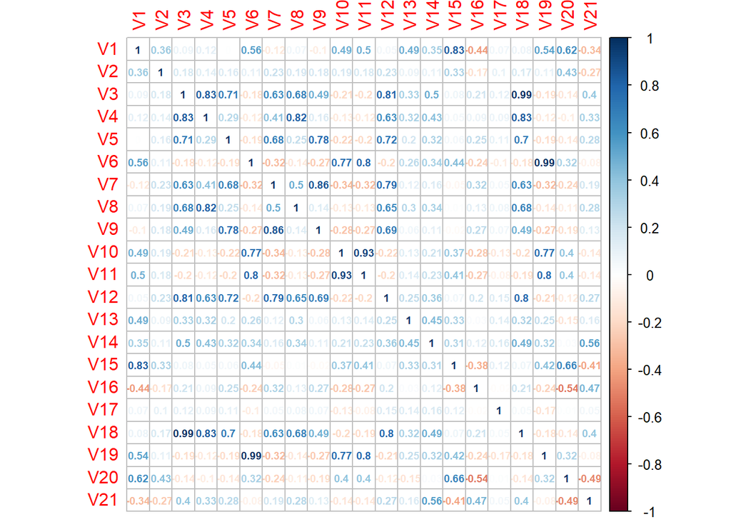

```r
corrplot(corr, method="number",number.cex = 0.6)
```

```r
View(corr)
```

- Most of the variables are having positive correlation rather than negative one.
- Some of them even strongly correlated, just like PURCHASES and ONEOFF_PURCHASES, indicating most customers spend their purchase in one-go, the same thing goes to PURCHASES_FREQUENCY and PURCHASES_INSTALLMENTS_FREQUENCY. It indicates that there some strong multicollinearity between them. But since we are not going regression model, it won’t be a problem.
- The PURCHASES and PURCHASES_TRX has strong correlation, indicating that the amount of purchase comes along with the transaction numbers.
- Some interesting finding can be also found between CASH_ADVANCE and the BALANCE. It seems that customer who has bigger balance will tend to have payment with cash in advance.
- TENURE seems has weak correlation with other variables, it seems TENURE did not affected by the customer’s behavior.

The most popular dimensionality reduction technique is PCA or principal component analysis, which is linear dimensionality reduction. This can be obtained by computing the top eigenvectors the data matrix.

we will standardize the data first.

```r
scaled_data<-scale(clean_data)
```

[output not shown]

```r
data_pca<-prcomp(scaled_data)
summary(data_pca)
```

```
## Importance of components:
##                           PC1    PC2    PC3     PC4     PC5     PC6    PC7
## Standard deviation     2.5845 2.2092 1.5041 1.24356 1.08625 0.93952 0.8767
## Proportion of Variance 0.3181 0.2324 0.1077 0.07364 0.05619 0.04203 0.0366
## Cumulative Proportion  0.3181 0.5505 0.6582 0.73186 0.78805 0.83008 0.8667
##                            PC8     PC9    PC10    PC11    PC12    PC13    PC14
## Standard deviation     0.80005 0.70863 0.63619 0.58108 0.45723 0.41430 0.37443
## Proportion of Variance 0.03048 0.02391 0.01927 0.01608 0.00996 0.00817 0.00668
## Cumulative Proportion  0.89716 0.92107 0.94035 0.95643 0.96638 0.97456 0.98123
##                           PC15    PC16    PC17    PC18    PC19    PC20    PC21
## Standard deviation     0.34444 0.32707 0.25737 0.24780 0.18167 0.06886 0.05606
## Proportion of Variance 0.00565 0.00509 0.00315 0.00292 0.00157 0.00023 0.00015
## Cumulative Proportion  0.98688 0.99197 0.99513 0.99805 0.99962 0.99985 1.00000
```

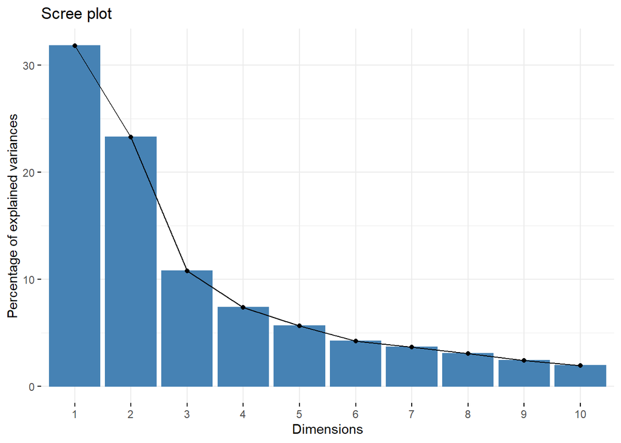

```r
fviz_eig(data_pca)
```

```r
value<-eigen(corr)$values
```

**Building clusters using k means**

```r
cluster_two <- kmeans(scaled_data,2)
cluster_three <- kmeans(scaled_data,3)
cluster_four <- kmeans(scaled_data,4)
cluster_five <- kmeans(scaled_data,5)
cluster_six <- kmeans(scaled_data,6)

clean_data<-data.frame(clean_data)

all_clusters<-cbind(clean_data,clust_3=cluster_three$cluster,clust_4=cluster_four$cluster,clust_5=cluster_five$cluster ,clust_6=cluster_six$cluster)
```

**Creating Profile**

```r
all_var<- c("BALANCE",
            "BALANCE_FREQUENCY",
            "PURCHASES",
            "ONEOFF_PURCHASES",
            "INSTALLMENTS_PURCHASES",
            "CASH_ADVANCE","PURCHASES_FREQUENCY",
            "ONEOFF_PURCHASES_FREQUENCY",
            "PURCHASES_INSTALLMENTS_FREQUENCY",
            "CASH_ADVANCE_FREQUENCY",
            "CASH_ADVANCE_TRX",
            "PURCHASES_TRX",
            "CREDIT_LIMIT",
            "PAYMENTS",
            "MINIMUM_PAYMENTS",
            "TENURE",
            "MONTHLY_AVG_PURCHASE",
            "MONTHLY_ADV_AMOUNT",
            "Limit_usage",
            "minpay_ratio")
```

```r
lengths<-tabular(1+factor(clust_3)+factor(clust_4)+factor(clust_5)+factor(clust_6)~Heading()*length*All(clean_data[1]),data=all_clusters)
means<-tabular(1+factor(clust_3)+factor(clust_4)+factor(clust_5)+factor(clust_6)~Heading()*mean*All(clean_data[all_var]),data=all_clusters)

tab_form<-cbind(lengths,means)
tab_form2<- as.data.frame.matrix(tab_form)

rownames(tab_form2)<-c("overall","cluster3_1","cluster3_2","cluster3_3","cluster4_1","cluster4_2","cluster4_3","cluster4_4","cluster5_1","cluster5_2","cluster5_3","cluster5_4","cluster5_5","cluster6_1","cluster6_2","cluster6_3","cluster6_4","cluster6_5","cluster6_6")

colnames(tab_form2)<- c("BALANCE",
                  "BALANCE_FREQUENCY",
                  "PURCHASES",
                  "ONEOFF_PURCHASES",
                  "INSTALLMENTS_PURCHASES",
                  "CASH_ADVANCE","PURCHASES_FREQUENCY",
                  "ONEOFF_PURCHASES_FREQUENCY",
                  "PURCHASES_INSTALLMENTS_FREQUENCY",
                  "CASH_ADVANCE_FREQUENCY",
                  "CASH_ADVANCE_TRX",
                  "PURCHASES_TRX",
                  "CREDIT_LIMIT",
                  "PAYMENTS",
                  "MINIMUM_PAYMENTS",
                  "TENURE",
                  "MONTHLY_AVG_PURCHASE",
                  "MONTHLY_ADV_AMOUNT",
                  "Limit_usage",
                  "minpay_ratio")
profiling<- t(tab_form2)
```